# Graduate Rotational Internship Program:

# THE SPARKS FOUNDATION

Githublink:-github.com/AditiMondal1110

**Task No:-3.Exploratory Data Analysis -Retail,Perform'Exploratory Data Analysis' on dataset SampleSuperStore.**

**Author-Aditi Mondal**

**Goal:- As a business manager ,try to find out the weak areas where u can work to make more profit.**

**What all business problem you can derive by exploring the data?**

# Importing All The Libraries

```python
import pandas as pd
import numpy as np
import seaborn as sns
import matplotlib.pyplot as plt
%matplotlib inline
import warnings # current version of seaborn generates a bunch of warnings that we'll ignore
warnings.filterwarnings('ignore')
```

# Reading DataSet to Jupiter Notebook

```python
pd.read_csv("./data/SampleSuperstore.csv")
print("Data imported sucessfully")
```

```
Data imported sucessfully
```

```python
ss_df=pd.read_csv("./data/SampleSuperstore.csv")
ss_df.head(5)
```

|  | Ship Mode | Segment | Country | City | State | Postal Code | Region | Category | Sub-Category | Sales | Quantity | Discount | Profit |
| --- | --- | --- | --- | --- | --- | --- | --- | --- | --- | --- | --- | --- | --- |
| 0 | Second Class | Consumer | United States | Henderson | Kentucky | 42420 | South | Furniture | Bookcases | 261.9600 | 2 | 0.00 | 41.9136 |
| 1 | Second Class | Consumer | United States | Henderson | Kentucky | 42420 | South | Furniture | Chairs | 731.9400 | 3 | 0.00 | 219.5820 |
| 2 | Second Class | Corporate | United States | Los Angeles | California | 90036 | West | Office Supplies | Labels | 14.6200 | 2 | 0.00 | 6.8714 |
| 3 | Standard Class | Consumer | United States | Fort Lauderdale | Florida | 33311 | South | Furniture | Tables | 957.5775 | 5 | 0.45 | -383.0310 |
| 4 | Standard Class | Consumer | United States | Fort Lauderdale | Florida | 33311 | South | Office Supplies | Storage | 22.3680 | 2 | 0.20 | 2.5164 |

```python
ss_df.tail(5)
```

|  | Ship Mode | Segment | Country | City | State | Postal Code | Region | Category | Sub-Category | Sales | Quantity | Discount | Profit |
| --- | --- | --- | --- | --- | --- | --- | --- | --- | --- | --- | --- | --- | --- |
| 9989 | Second Class | Consumer | United States | Miami | Florida | 33180 | South | Furniture | Furnishings | 25.248 | 3 | 0.2 | 4.1028 |
| 9990 | Standard Class | Consumer | United States | Costa Mesa | California | 92627 | West | Furniture | Furnishings | 91.960 | 2 | 0.0 | 15.6332 |
| 9991 | Standard Class | Consumer | United States | Costa Mesa | California | 92627 | West | Technology | Phones | 258.576 | 2 | 0.2 | 19.3932 |
| 9992 | Standard Class | Consumer | United States | Costa Mesa | California | 92627 | West | Office Supplies | Paper | 29.600 | 4 | 0.0 | 13.3200 |
| 9993 | Second Class | Consumer | United States | Westminster | California | 92683 | West | Office Supplies | Appliances | 243.160 | 2 | 0.0 | 72.9480 |

# Checking the summary of my data

```python
ss_df.columns
```

```
Index(['Ship Mode', 'Segment', 'Country', 'City', 'State', 'Postal Code',
       'Region', 'Category', 'Sub-Category', 'Sales', 'Quantity', 'Discount',
       'Profit'],
      dtype='object')
```

```python
ss_df.describe()
```

|  | Postal Code | Sales | Quantity | Discount | Profit |
| --- | --- | --- | --- | --- | --- |
| count | 9994.000000 | 9994.000000 | 9994.000000 | 9994.000000 | 9994.000000 |
| mean | 55190.379428 | 229.858001 | 3.789574 | 0.156203 | 28.656896 |
| std | 32063.693350 | 623.245101 | 2.225110 | 0.206452 | 234.260108 |
| min | 1040.000000 | 0.444000 | 1.000000 | 0.000000 | -6599.978000 |
| 25% | 23223.000000 | 17.280000 | 2.000000 | 0.000000 | 1.728750 |
| 50% | 56430.500000 | 54.490000 | 3.000000 | 0.200000 | 8.666500 |
| 75% | 90008.000000 | 209.940000 | 5.000000 | 0.200000 | 29.364000 |
| max | 99301.000000 | 22638.480000 | 14.000000 | 0.800000 | 8399.976000 |

```python
ss_df.info()
```

```
<class 'pandas.core.frame.DataFrame'>
RangeIndex: 9994 entries, 0 to 9993
Data columns (total 13 columns):
 #   Column        Non-Null Count  Dtype
---  ------        --------------  -----
 0   Ship Mode     9994 non-null   object
 1   Segment       9994 non-null   object
 2   Country       9994 non-null   object
 3   City          9994 non-null   object
 4   State         9994 non-null   object
 5   Postal Code   9994 non-null   int64
 6   Region        9994 non-null   object
 7   Category      9994 non-null   object
 8   Sub-Category  9994 non-null   object
 9   Sales         9994 non-null   float64
 10  Quantity      9994 non-null   int64
 11  Discount      9994 non-null   float64
 12  Profit        9994 non-null   float64
dtypes: float64(3), int64(2), object(8)
memory usage: 1015.1+ KB
```

# Checking for the null values

```python
ss_df.isnull().sum()
```

```
Ship Mode       0
Segment         0
Country         0
City            0
State           0
Postal Code     0
Region          0
Category        0
Sub-Category    0
Sales           0
Quantity        0
Discount        0
Profit          0
dtype: int64
```

```python
ss_df['Ship Mode'].value_counts()
```

```
Standard Class    5968
Second Class      1945
First Class       1538
Same Day           543
Name: Ship Mode, dtype: int64
```

```python
ss_df['Segment'].value_counts()
```

```
Consumer       5191
Corporate      3020
Home Office    1783
Name: Segment, dtype: int64
```

```python
ss_df['City'].value_counts()
```

```
New York City    915
Los Angeles      747
Philadelphia     537
San Francisco    510
Seattle          428
                ...
Lindenhurst        1
Cedar Rapids       1
Kissimmee          1
Glenview           1
Ormond Beach       1
Name: City, Length: 531, dtype: int64
```

```python
ss_df['Region'].value_counts()
```

```
West       3203
East       2848
Central    2323
South      1620
Name: Region, dtype: int64
```

```python
ss_df['Category'].value_counts()
```

```
Office Supplies    6026
Furniture          2121
Technology         1847
Name: Category, dtype: int64
```

```python
ss_df['Sub-Category'].value_counts()
```

```
Binders        1523
Paper          1370
Furnishings     957
Phones          889
Storage         846
Art             796
Accessories     775
Chairs          617
Appliances      466
Labels          364
Tables          319
Envelopes       254
Bookcases       228
Fasteners       217
Supplies        190
Machines        115
Copiers          68
Name: Sub-Category, dtype: int64
```

# Checking for duplicate value

```python
ss_df.duplicated().sum()
```

```
17
```

# droping the duplicate rows

```python
ss_df.drop_duplicates()
```

|  | Ship Mode | Segment | Country | City | State | Postal Code | Region | Category | Sub-Category | Sales | Quantity | Discount | Profit |
| --- | --- | --- | --- | --- | --- | --- | --- | --- | --- | --- | --- | --- | --- |
| 0 | Second Class | Consumer | United States | Henderson | Kentucky | 42420 | South | Furniture | Bookcases | 261.9600 | 2 | 0.00 | 41.9136 |
| 1 | Second Class | Consumer | United States | Henderson | Kentucky | 42420 | South | Furniture | Chairs | 731.9400 | 3 | 0.00 | 219.5820 |
| 2 | Second Class | Corporate | United States | Los Angeles | California | 90036 | West | Office Supplies | Labels | 14.6200 | 2 | 0.00 | 6.8714 |
| 3 | Standard Class | Consumer | United States | Fort Lauderdale | Florida | 33311 | South | Furniture | Tables | 957.5775 | 5 | 0.45 | -383.0310 |
| 4 | Standard Class | Consumer | United States | Fort Lauderdale | Florida | 33311 | South | Office Supplies | Storage | 22.3680 | 2 | 0.20 | 2.5164 |
| ... | ... | ... | ... | ... | ... | ... | ... | ... | ... | ... | ... | ... | ... |
| 9989 | Second Class | Consumer | United States | Miami | Florida | 33180 | South | Furniture | Furnishings | 25.2480 | 3 | 0.20 | 4.1028 |
| 9990 | Standard Class | Consumer | United States | Costa Mesa | California | 92627 | West | Furniture | Furnishings | 91.9600 | 2 | 0.00 | 15.6332 |
| 9991 | Standard Class | Consumer | United States | Costa Mesa | California | 92627 | West | Technology | Phones | 258.5760 | 2 | 0.20 | 19.3932 |
| 9992 | Standard Class | Consumer | United States | Costa Mesa | California | 92627 | West | Office Supplies | Paper | 29.6000 | 4 | 0.00 | 13.3200 |
| 9993 | Second Class | Consumer | United States | Westminster | California | 92683 | West | Office Supplies | Appliances | 243.1600 | 2 | 0.00 | 72.9480 |

9977 rows × 13 columns

```python
ss_df.nunique()
```

```
Ship Mode          4
Segment            3
Country            1
City             531
State             49
Postal Code      631
Region             4
Category           3
Sub-Category      17
Sales           5825
Quantity          14
Discount          12
Profit          7287
dtype: int64
```

```python
ss_df.nunique().sum()
```

```
14381
```

# Dropping the irrelevant columns

```python
ss_df.drop(['Postal Code'],axis=1,inplace=True)
```

```python
ss_df.columns
```

```
Index(['Ship Mode', 'Segment', 'Country', 'City', 'State', 'Region',
       'Category', 'Sub-Category', 'Sales', 'Quantity', 'Discount', 'Profit'],
      dtype='object')
```

# Checking the statistical relation between various rows and columns

**Covariance is when two vriables vary with each other ,whereas corelation is when the change in one variable results in the change in another variable.**

```python
ss_df.corr()
```

|  | Sales | Quantity | Discount | Profit |
| --- | --- | --- | --- | --- |
| Sales | 1.000000 | 0.200795 | -0.028190 | 0.479064 |
| Quantity | 0.200795 | 1.000000 | 0.008623 | 0.066253 |
| Discount | -0.028190 | 0.008623 | 1.000000 | -0.219487 |
| Profit | 0.479064 | 0.066253 | -0.219487 | 1.000000 |

```python
ss_df.cov()
```

|  | Sales | Quantity | Discount | Profit |
| --- | --- | --- | --- | --- |
| Sales | 388434.455308 | 278.459923 | -3.627228 | 69944.096586 |
| Quantity | 278.459923 | 4.951113 | 0.003961 | 34.534769 |
| Discount | -3.627228 | 0.003961 | 0.042622 | -10.615173 |
| Profit | 69944.096586 | 34.534769 | -10.615173 | 54877.798055 |

# Data Visualization

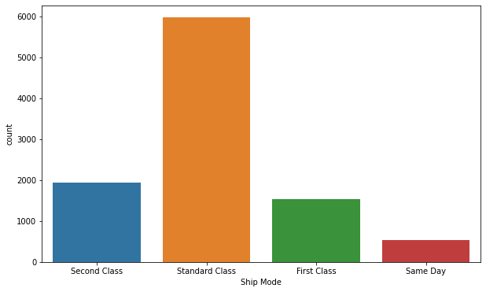

```python
plt.figure(figsize=(10,6))
sns.countplot(x='Ship Mode',data=ss_df)
plt.show()
```

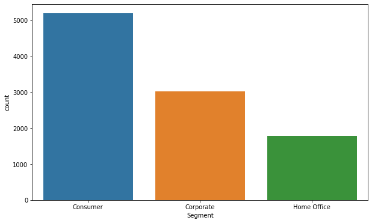

```python
plt.figure(figsize=(10,6))
sns.countplot(x='Segment',data=ss_df)
plt.show()
```

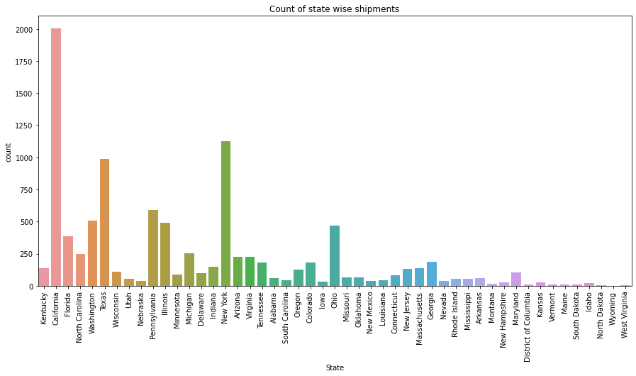

```python
plt.figure(figsize=(15,7))
sns.countplot(x=ss_df['State'])
plt.xticks(rotation=90)
plt.title('Count of state wise shipments')
plt.show()
```

# Visualization Understanding of count of state wise Shipments:

**State wise California has highest sales:**

**States like Texas ,New York ,etc. are active in business.**

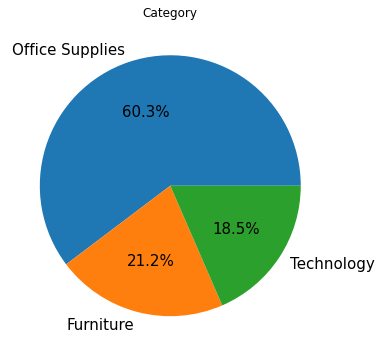

```python
plt.figure(figsize=(9,6))
textprops={'fontsize':15}
plt.title('Category')
plt.pie(ss_df['Category'].value_counts(),labels=ss_df['Category'].value_counts().index,autopct='%1.1f%%',textprops=textprops)
plt.show()
```

# This pie graph indicates that the office supplies have the highest demand and others are comparatively less in demand.

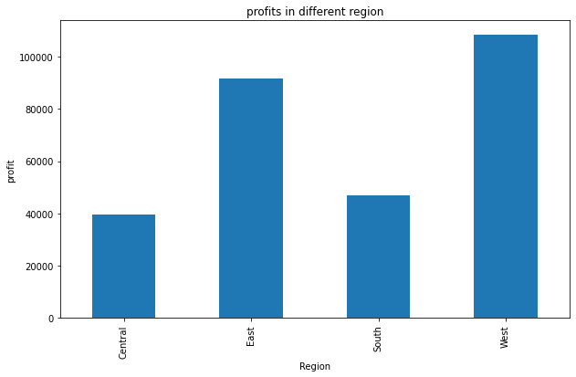

```python
plt.figure(figsize=(10,6))
ss_df.groupby('Region')['Profit'].agg(sum).plot(kind='bar')
plt.ylabel('profit')
plt.title('profits in different region')
plt.show()
```

# Overview Understanding of Profit in different Region Chart

**West gernerates most of the profit folowed by East.**

**Central and southern region are generating less profit as compared to the Eastern and Western Region.**

**Increase the sales in central and southern region in order to generate more profit in three region.**

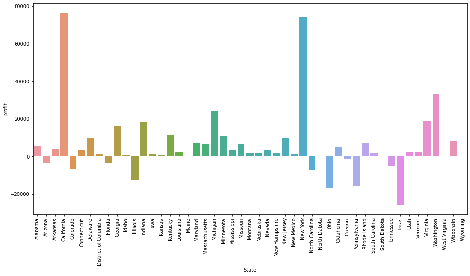

```python
sp=ss_df.groupby('State')['Profit'].sum()
plt.figure(figsize=(16,8))
sns.barplot(x=sp.index,y=sp.values)
plt.xticks(rotation=90)
plt.ylabel('profit')
plt.show()
```

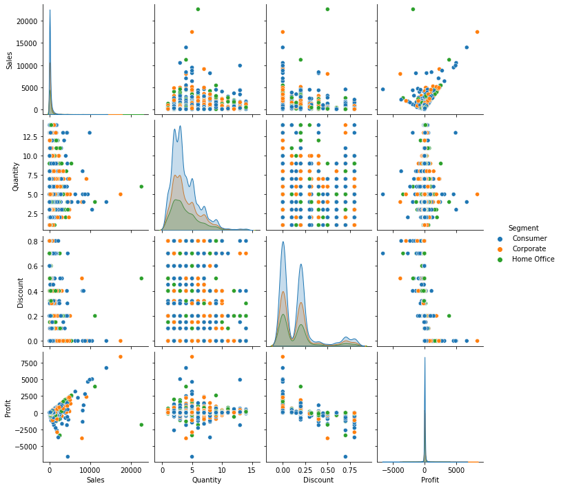

```python
sns.pairplot(ss_df,hue='Segment')
```

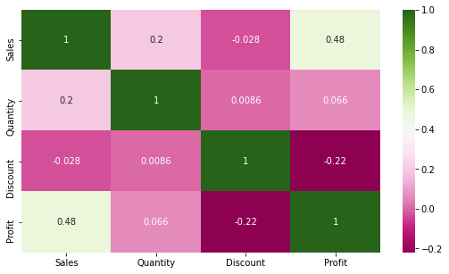

```python
plt.figure(figsize=(9,5))
sns.heatmap(ss_df.corr(),annot=True,cmap="PiYG")
```

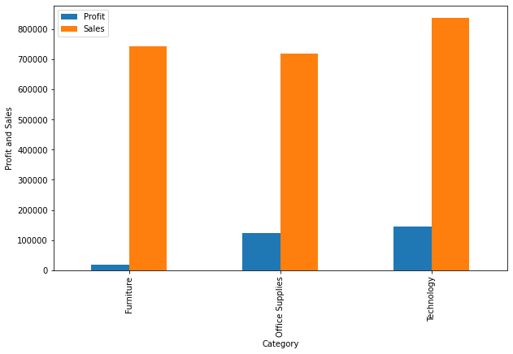

```python
ss_df.groupby(['Category'])[['Profit','Sales']].agg(sum).plot(kind='bar',figsize=(10,6))
plt.ylabel('Profit and Sales')
plt.show()
```

**This shows that furniture is generating very less profit**

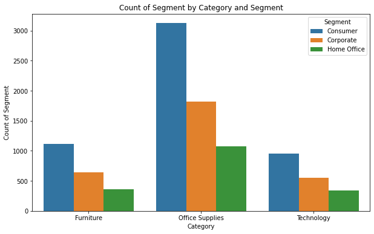

```python
plt.figure(figsize=(10,6))
sns.countplot(x='Category',hue='Segment',data=ss_df)
plt.ylabel('Count of Segment')
plt.title('Count of Segment by Category and Segment')
```

**The highest purchases are in consumer segment whereas home office segment has the least purchases in each category.We need to focus on the corporate and home office segment as well to increase our sales and profit.**

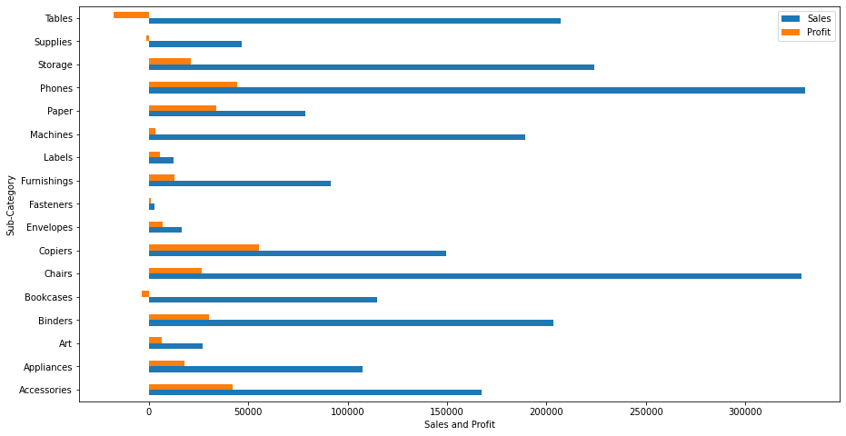

```python
ss_df.groupby('Sub-Category')[['Sales','Profit']].agg(sum).plot(kind='barh',figsize=(15,8))
plt.ylabel('Sub-Category')
plt.xlabel('Sales and Profit')
plt.show()
```

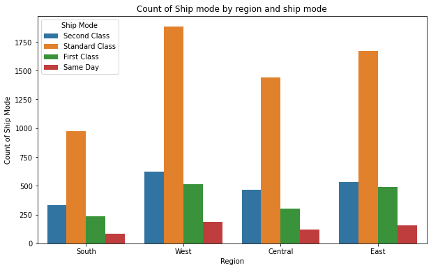

```python
plt.figure(figsize=(10,6))
sns.countplot(x='Region',hue='Ship Mode',data=ss_df)
plt.ylabel('Count of Ship Mode')
plt.title('Count of Ship mode by region and ship mode')
```

**Least Sales are in Southern region ,we can attract this region by offering more discount.Standard mode of shipment is opted by most of the customers in each region.**

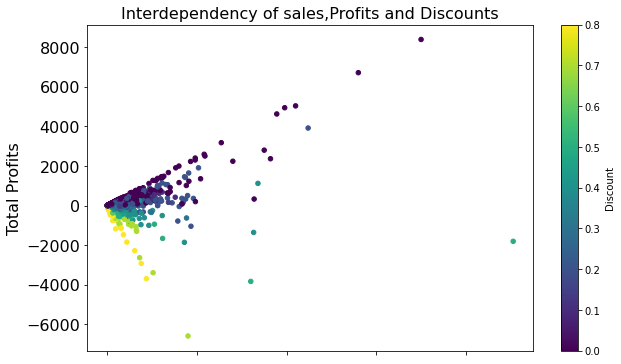

```python
ss_df.plot(kind="scatter",figsize=(10,6),x="Sales",y="Profit",c="Discount",s=20,fontsize=16,colormap="viridis")
plt.ylabel('Total Profits',fontsize=16)
plt.title("Interdependency of sales,Profits and Discounts",fontsize=16)
plt.show()
```

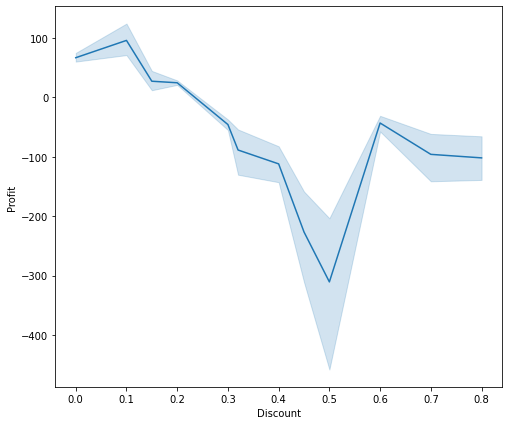

```python
plt.figure(figsize=(8,7))
sns.lineplot(ss_df['Discount'],ss_df['Profit'],data=ss_df)
```

# **To keep the profit margins the percentage of discount should be less than 25%.**

# Bussiness Understanding:

1.**Higher number of buyers are from New York and California.**

2.**Most customers buy 2 or 3 quantity only.**

3.**Max discount give is 0 to 20%.**

4.**Segments wise sales are almost in every region.**

6.**Profit and sales are maximum in customer segments and minimum in home office segments.**

# Weak Areas Where You Can Work To Make More Profit.

1.**We should limit the sales of furniture and increase that of office supplies and technology as it is generating very less profit as compared to its sales.**

2.**In the sub-categories we are facing huge loss on tables son that should be minimized.**

3.**The sales and profit in Southern and Central regiobn are less so we should give morw incentives like discount in order to increase sales,hence profit will increase.**

4.**After the highest sales in California we have high value of potential customers in Texas and New York so we should concentrate more on these states to increase our sales and profit.**

5.**We have highest purchases in consumer segment biut we should also concentrate on corporate and home office segments to increase our sales and profit.**

6.**Few states like North Dakorta ,Wyoming and West Virgilina have less or no sales at all so we also need to focus on these states.**

7.**The percentage of discount offered should not be more than 25%,otherwise loss is faced.

# Main Focous Should Be On The Following Things:

1.**Need to reduce costs.**

2.**Need to increase productivity.**

3..**Need to increse efficient product.**

4.**Need to give extra effort in segment area.**